# IODS course project

Pekka Tolli

# Week 1 - when the fun begins

## IODS - The most awesome course of the season :)

Introduction to open data science is a new exciting course. I am thrilled to take it. My brand new GitHub account can be found: https://ptolli.github.io/IODS-project/

The first week exercise was nice an easy. Next week it will probably be a bit more hard work

```r
Data science is cool :D
```

# Week 2 - when the stuff gets real

The second week exercise was quite a bit more demanding than the first one. However, the Data Camp stuff gave a great starting point and just following their logic it was quite nice and clear to do the data wrangling and analysis

Here is my second week r-script: https://github.com/ptolli/IODS-project/blob/master/Data/Week2.R and the data file: https://github.com/ptolli/IODS-project/blob/master/Data/data2

## Data wrangling

First I read learning2014 data from http://www.helsinki.fi/~kvehkala/JYTmooc/JYTOPKYS3-data.txt into R and explore the data set with basic characteristics such as str and dim

I created a subset from the master data including variables gender, age, attitude, deep, stra, surf and points by combining questions in the learning2014 data, as defined in the datacamp exercises.

Then i saved the subset as data2.csv

## Data analysis part

First I download the my new dataset “data2” to R and checked its structure.

The i put together a graphical overview of the data and with summaries of the variables + short descriptions of the outputs, commenting on the varibles and their relationships

I created a linear regrssion model with three variables. For that I took three variables with highest correlation with “points” variable (stra, surf and attitude). I examided the summary of the model and interpreted the results. It appeared variable surf did not have statistically significant relationship with the dependent variable, so i omitted that and created a new model with two remaining variables.

With the new model (model2), it appears that studying attitude and strategic approach explain around 13.5% of the variation of points. Based on the model, the points can be estimated by having 0.38 times attitude + 1.934 times the strategic approach scores + 2.67 (intercept)

Last I produced some nice diagnostic plots: Residuals vs Fitted values, Normal QQ-plot and Residuals vs Leverage.

Nice stuff :)

# Week 3 - blood and tears with logistic regression

## Data analysis - explaining high alcohol use of students with logistic regression model

On this week’s exercise I’ll explore the explaining variables for the student high use of alcohol. For that I’l apply logistic regression model The data of the exercise is from a real student data from Portugal.

You can find the data [here](http://s3.amazonaws.com/assets.datacamp.com/production/course_2218/datasets/alc.txt) and the descriptions of the variables etc. from [here](https://archive.ics.uci.edu/ml/datasets/Student+Performance).

## Part 1: Load the data set and explore its basics:

```r
alc_data <- read.table("C:/Users/pekka/Documents/GitHub/IODS-project/Data/alc_data.csv", sep=",", header=TRUE)
str(alc_data)
```

```
## 'data.frame':    382 obs. of  36 variables:
##  $ X         : int  1 2 3 4 5 6 7 8 9 10 ...
##  $ school    : Factor w/ 2 levels "GP","MS": 1 1 1 1 1 1 1 1 1 1 ...
##  $ sex       : Factor w/ 2 levels "F","M": 1 1 1 1 1 2 2 1 2 2 ...
##  $ age       : int  18 17 15 15 16 16 16 17 15 15 ...
##  $ address   : Factor w/ 2 levels "R","U": 2 2 2 2 2 2 2 2 2 2 ...
##  $ famsize   : Factor w/ 2 levels "GT3","LE3": 1 1 2 1 1 2 2 1 2 1 ...
##  $ Pstatus   : Factor w/ 2 levels "A","T": 1 2 2 2 2 2 2 1 1 2 ...
##  $ Medu      : int  4 1 1 4 3 4 2 4 3 3 ...
##  $ Fedu      : int  4 1 1 2 3 3 2 4 2 4 ...
##  $ Mjob      : Factor w/ 5 levels "at_home","health",..: 1 1 1 2 3 4 3 3 4 3 ...
##  $ Fjob      : Factor w/ 5 levels "at_home","health",..: 5 3 3 4 3 3 3 5 3 3 ...
##  $ reason    : Factor w/ 4 levels "course","home",..: 1 1 3 2 2 4 2 2 2 2 ...
##  $ nursery   : Factor w/ 2 levels "no","yes": 2 1 2 2 2 2 2 2 2 2 ...
##  $ internet  : Factor w/ 2 levels "no","yes": 1 2 2 2 1 2 2 1 2 2 ...
```

[output cut: 22 more lines]

```r
dim(alc_data)
```

```
## [1] 382  36
```

We have data set with 36 variables and ~380 observations. Very nice :)

## Part 2: Define the explaining variables:

Let’s choose four variables to see their relationship with alcohol consumption: 1. goout (going out with friends), 2. health (current health status), 3. absences - number of school absences and 4. sex (student’s sex).

..and look a bit how they appear

### Variable 1 - Going out

```r
prop.table(table(alc_data$goout, alc_data$high_use), margin=1)*100
```

```
##
##        FALSE     TRUE
##   1 87.50000 12.50000
##   2 84.84848 15.15152
##   3 81.30081 18.69919
##   4 52.43902 47.56098
##   5 40.74074 59.25926
```

```r
cor(alc_data$goout, alc_data$high_use)
```

```
## [1] 0.352999
```

```r
chisq.test(alc_data$goout, alc_data$high_use, correct=FALSE)
```

```
##
##  Pearson's Chi-squared test
##
## data:  alc_data$goout and alc_data$high_use
## X-squared = 56.085, df = 4, p-value = 1.924e-11
```

Based on the basic stats above, activity of going out seems to have strong positive correlation with alcohol usage.

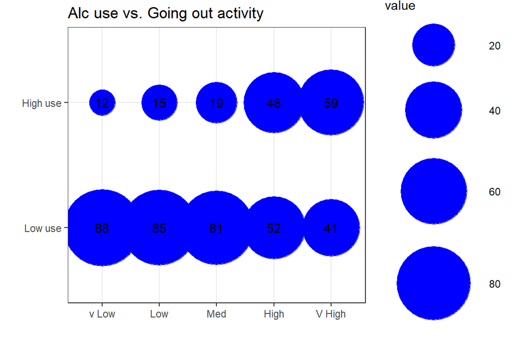

```r
goout_label <- c("v Low","Low","Med","High","V High")
Alc_use <- c("Low use","High use")
df <- expand.grid(goout_label, Alc_use)
df$value <- round(goout_use, digits=0)
g <- ggplot(df, aes(Var1, Var2)) + geom_point(aes(size = value), colour = "blue") + theme_bw() + xlab("") + ylab("")
g + scale_size_continuous(range=c(10,30)) + geom_text(aes(label = value)) + ggtitle("Alc use vs. Going out activity")
```

The visual cross-tabulation shows there higher the outgoing activity is, the higher the share of high use students

### Variable 2 - Health

```r
table(alc_data$health, alc_data$high_use)
```

```
##
##     FALSE TRUE
##   1    35   11
##   2    29   14
##   3    63   20
##   4    47   17
##   5    96   50
```

```r
health_use <- c(prop.table(table(alc_data$health, alc_data$high_use), margin=1)*100)
prop.table(table(alc_data$health, alc_data$high_use), margin=1)*100
```

```
##
##        FALSE     TRUE
##   1 76.08696 23.91304
##   2 67.44186 32.55814
##   3 75.90361 24.09639
##   4 73.43750 26.56250
##   5 65.75342 34.24658
```

```r
cor(alc_data$health, alc_data$high_use)
```

```
## [1] 0.0666294
```

```r
chisq.test(alc_data$health, alc_data$high_use, correct=FALSE)
```

```
##
##  Pearson's Chi-squared test
##
## data:  alc_data$health and alc_data$high_use
## X-squared = 3.9042, df = 4, p-value = 0.4191
```

Based on the basic stats above, there seems to be a very weak link between the current health and high alcohol usage.

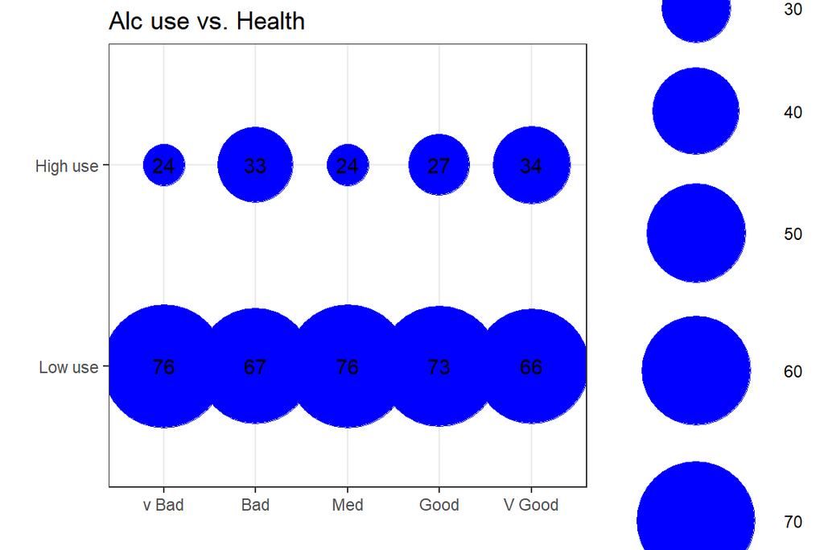

```r
health_label <- c("v Bad","Bad","Med","Good","V Good")
Alc_use <- c("Low use","High use")
df <- expand.grid(health_label, Alc_use)
df$value <- round(health_use, digits=0)

g <- ggplot(df, aes(Var1, Var2)) + geom_point(aes(size = value), colour = "blue") + theme_bw() + xlab("") + ylab("")
g + scale_size_continuous(range=c(10,30)) + geom_text(aes(label = value)) + ggtitle("Alc use vs. Health")
```

…which is also evident from the visualized cross-tabulation above

### Variable 3 - absences

```r
table(alc_data$absences, alc_data$high_use)
```

```
##
##      FALSE TRUE
##   0     94   22
##   1      2    1
##   2     54   13
##   3      2    4
##   4     36   15
##   5      4    0
##   6     19   11
##   7      6    2
##   8     13    8
##   9      3    0
##   10    12    5
##   11     1    1
##   12     6    4
```

[output cut: 19 more lines]

```r
goout_use <- c(prop.table(table(alc_data$absences, alc_data$high_use), margin=1)*100)
prop.table(table(alc_data$absences, alc_data$high_use), margin=1)*100
```

```
##
##          FALSE      TRUE
##   0   81.03448  18.96552
##   1   66.66667  33.33333
##   2   80.59701  19.40299
##   3   33.33333  66.66667
##   4   70.58824  29.41176
##   5  100.00000   0.00000
##   6   63.33333  36.66667
##   7   75.00000  25.00000
##   8   61.90476  38.09524
##   9  100.00000   0.00000
##   10  70.58824  29.41176
##   11  50.00000  50.00000
##   12  60.00000  40.00000
```

[output cut: 19 more lines]

```r
cor(alc_data$absences, alc_data$high_use)
```

```
## [1] 0.2229386
```

There is a medium/low correlation between absences and alcohol usage.

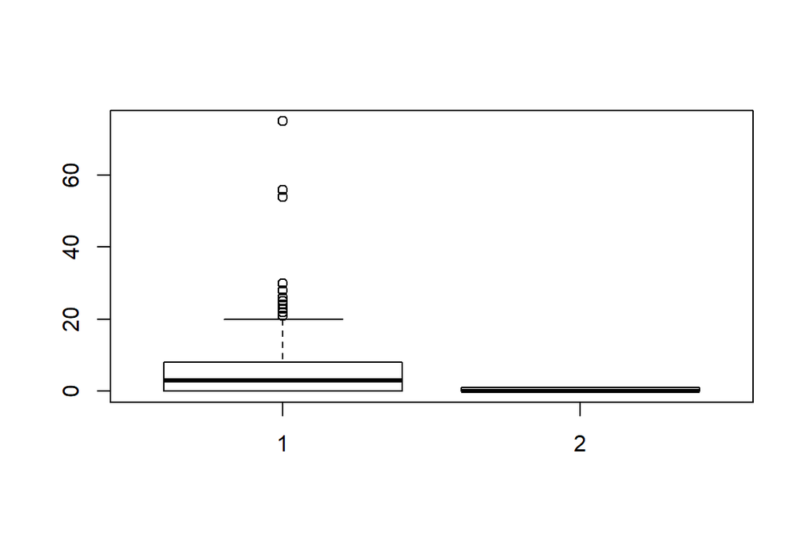

```r
boxplot(alc_data$absences, alc_data$high_use)
```

### Variable 4: sex

```r
table(alc_data$sex, alc_data$high_use)
```

```
##
##     FALSE TRUE
##   F   157   41
##   M   113   71
```

```r
sex_use <- c(prop.table(table(alc_data$sex, alc_data$high_use), margin=1)*100)
prop.table(table(alc_data$sex, alc_data$high_use), margin=1)*100
```

```
##
##        FALSE     TRUE
##   F 79.29293 20.70707
##   M 61.41304 38.58696
```

```r
chisq.test(alc_data$sex, alc_data$high_use, correct=FALSE)
```

```
##
##  Pearson's Chi-squared test
##
## data:  alc_data$sex and alc_data$high_use
## X-squared = 14.713, df = 1, p-value = 0.0001252
```

It appears, the sex has strong relationship with the alcohol consumption, with hypotehesis: male students are more likely high-users. Chi-squared test gives strong indication the distribution is not even.

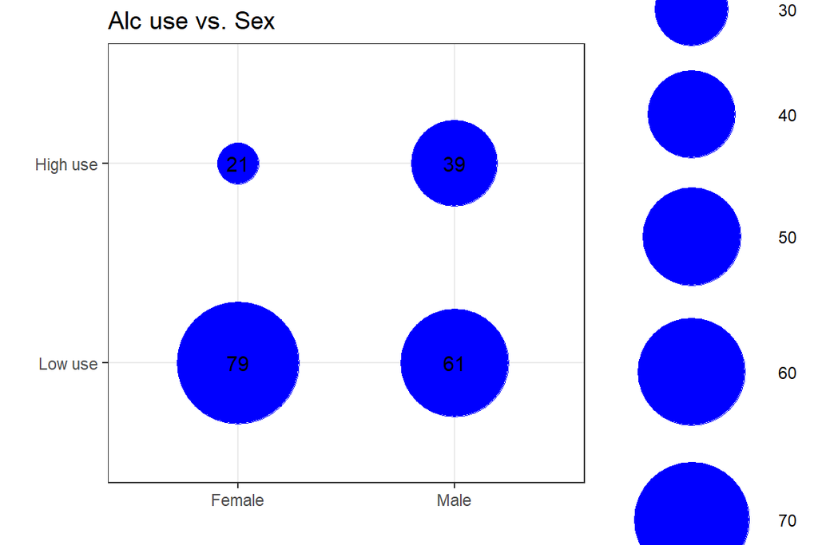

```r
sex_label <- c("Female","Male")
ef <- expand.grid(sex_label, Alc_use)
ef$value <- round(sex_use, digits=0)
g <- ggplot(ef, aes(Var1, Var2)) + geom_point(aes(size = value), colour = "blue") + theme_bw() + xlab("") + ylab("")
g + scale_size_continuous(range=c(10,30)) + geom_text(aes(label = value)) + ggtitle("Alc use vs. Sex")
```

### Let’s summarize the two most impactful variables in boxplot to have another angle to our hypthesis.

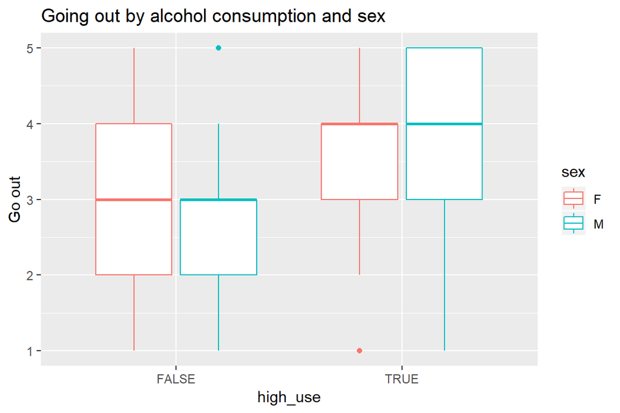

```r
g1<-ggplot(alc_data, aes(x = high_use, y = goout, col = sex))
g1 + geom_boxplot() + ylab("Go out") + ggtitle("Going out by alcohol consumption and sex")
```

overall, it looks some of my previous thinking get support from the data: sex and going out activity correlate with the high alcohol use. In addition, absences have somewhat medium link with alcohol use. However, my fourth hypothesis is not that much supported: current health does not have strong relationship with alcohol use.

## Part 3: Logistic model fitting

Now, fit the logistic model with the above selected variables

```r
m <- glm(high_use ~ goout + health + absences + sex, data = alc_data, family = "binomial")
```

Let’s examine the model

```r
summary(m)
```

```
##
## Call:
## glm(formula = high_use ~ goout + health + absences + sex, family = "binomial",
##     data = alc_data)
##
## Deviance Residuals:
##     Min       1Q   Median       3Q      Max
## -1.8894  -0.7752  -0.5137   0.7788   2.4795
##
## Coefficients:
##             Estimate Std. Error z value Pr(>|z|)
## (Intercept) -4.59285    0.59058  -7.777 7.43e-15 ***
## goout        0.75154    0.12075   6.224 4.85e-10 ***
## health       0.09493    0.09297   1.021 0.307189
## absences     0.06624    0.01707   3.881 0.000104 ***
## sexM         0.96317    0.26040   3.699 0.000217 ***
## ---
## Signif. codes:  0 '***' 0.001 '**' 0.01 '*' 0.05 '.' 0.1 ' ' 1
##
## (Dispersion parameter for binomial family taken to be 1)
##
##     Null deviance: 462.21  on 381  degrees of freedom
## Residual deviance: 380.39  on 377  degrees of freedom
## AIC: 390.39
##
## Number of Fisher Scoring iterations: 4
```

```r
coef(m)
```

```
## (Intercept)       goout      health    absences        sexM
## -4.59285459  0.75153986  0.09493465  0.06623947  0.96316549
```

### Odds ratios and coefficients of model 1

Let’s explore the odds ratios based on the coefficients:

```r
OR <- coef(m) %>% exp
OR
```

```
## (Intercept)       goout      health    absences        sexM
##  0.01012392  2.12026241  1.09958699  1.06848256  2.61997688
```

### Confidence intervals of model 1

```r
CI<-confint(m) %>% exp
CI
```

```
##                   2.5 %     97.5 %
## (Intercept) 0.003028195 0.03082534
## goout       1.683517411 2.70562367
## health      0.917762198 1.32259233
## absences    1.035723987 1.10823443
## sexM        1.582326759 4.40207093
```

Going out conf. int is 1.7-2.7. SexM has very wide conf. int. with 1.6-4.4 given variables binary nature

### Better version of the model = model 2

Create a new model by dropping the statistically insignificant variable:

```r
m2 <- glm(high_use ~ goout + absences + sex, data = alc_data, family = "binomial")
summary(m2)
```

```
##
## Call:
## glm(formula = high_use ~ goout + absences + sex, family = "binomial",
##     data = alc_data)
##
## Deviance Residuals:
##     Min       1Q   Median       3Q      Max
## -1.8180  -0.7872  -0.5325   0.7930   2.4627
##
## Coefficients:
##             Estimate Std. Error z value Pr(>|z|)
## (Intercept) -4.26004    0.48359  -8.809  < 2e-16 ***
## goout        0.74880    0.12058   6.210 5.30e-10 ***
## absences     0.06601    0.01694   3.897 9.73e-05 ***
## sexM         1.00074    0.25778   3.882 0.000104 ***
## ---
## Signif. codes:  0 '***' 0.001 '**' 0.01 '*' 0.05 '.' 0.1 ' ' 1
##
## (Dispersion parameter for binomial family taken to be 1)
##
##     Null deviance: 462.21  on 381  degrees of freedom
## Residual deviance: 381.44  on 378  degrees of freedom
## AIC: 389.44
##
## Number of Fisher Scoring iterations: 4
```

```r
coef(m2)
```

```
## (Intercept)       goout    absences        sexM
## -4.26004047  0.74880103  0.06601437  1.00073889
```

nice, now all coefficients are statistically significant, cool

```r
OR <- coef(m2) %>% exp
OR
```

```
## (Intercept)       goout    absences        sexM
##  0.01412173  2.11446331  1.06824207  2.72029108
```

```r
CI<-confint(m2) %>% exp
CI
```

```
##                  2.5 %     97.5 %
## (Intercept) 0.00524355 0.03505304
## goout       1.67942499 2.69728574
## absences    1.03562651 1.10770851
## sexM        1.65206212 4.54868006
```

```r
confint <-cbind(OR, CI)
confint
```

```
##                     OR      2.5 %     97.5 %
## (Intercept) 0.01412173 0.00524355 0.03505304
## goout       2.11446331 1.67942499 2.69728574
## absences    1.06824207 1.03562651 1.10770851
## sexM        2.72029108 1.65206212 4.54868006
```

It looks the odds ratios are quite close to the ones in the first model. That was expected because we omitted just one variable with low statististical significance. Also the confidence intervals are close to the ones in the model1

### Predictions with the model2

And now to testing the predictive power of my model:

```r
probabilities <- predict(m2, type = "response")
alc_data <- mutate(alc_data, probability = probabilities)
alc_data <- mutate(alc_data, prediction = probability>0.5)
table(high_use = alc_data$high_use, prediction = alc_data$prediction)
```

```
##         prediction
## high_use FALSE TRUE
##    FALSE   255   15
##    TRUE     66   46
```

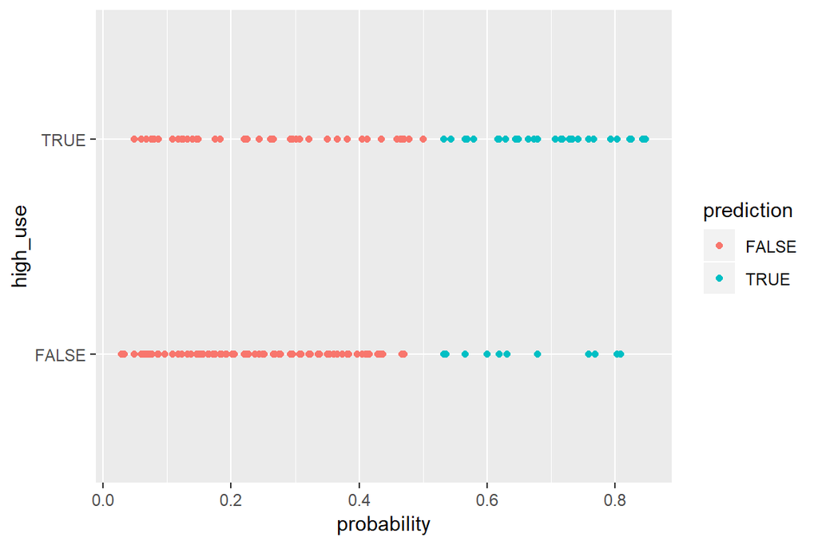

```r
g <- ggplot(alc_data, aes(x = probability, y = high_use, col = prediction))

g + geom_point() + aes(col = prediction)
```

Based on the plotting, the model seems to be working fairly well. As stated above, it has a tendency to classify some high users to low users, i.e. false negative outcome.

### Tabulate the target variable versus the predictions

```r
round(table(high_use = alc_data$high_use, prediction = alc_data$prediction) %>% prop.table %>% addmargins, digits = 2)
```

```
##         prediction
## high_use FALSE TRUE  Sum
##    FALSE  0.67 0.04 0.71
##    TRUE   0.17 0.12 0.29
##    Sum    0.84 0.16 1.00
```

It appears the model gives 79% of the observations right classification and to the rest 21% a wrong. False negative appreas to be more likely error than false positive.

```r
loss_func <- function(class, prob) {
  n_wrong <- abs(class - prob) > 0.5
  mean(n_wrong)
}
```

### Loss ratio and predictive power

call loss_func to compute the average number of wrong predictions in the (training) data

```r
loss_func(class = alc_data$high_use, prob = alc_data$probability)
```

```
## [1] 0.2120419
```

It appears, the model is fairly good in predicting the alcohol high use. Around 21% of the observations were incorrectly classified. With systematic proportional guessing (stating all observations are low use), one could get around 70% right given the low-use proportion is 70%.

```r
table(alc_data$high_use)
```

```
##
## FALSE  TRUE
##   270   112
```

### Bonus: let’s finally do the cross-validation.

```r
library(boot)
cv <- cv.glm(data = alc_data, cost = loss_func, glmfit = m2, K = 10)
cv
```

[output not shown]

[output cut: 121 more lines]

```r
cv$delta[1]
```

```
## [1] 0.2068063
```

With 10-fold cross-validation the prediction error is around 0.20-0.22. That is smaller than in the data camp exercise. Very nice

# Week 4 - total clusterfun

## Data analysis

On this week’s exercise I’ll explore the Boston crime data set from MASS library. I’ll do cluster analysis of the data set.

## Part 1: Explore the basics of the dataset:

```r
str(Boston)
```

```
## 'data.frame':    506 obs. of  14 variables:
##  $ crim   : num  0.00632 0.02731 0.02729 0.03237 0.06905 ...
##  $ zn     : num  18 0 0 0 0 0 12.5 12.5 12.5 12.5 ...
##  $ indus  : num  2.31 7.07 7.07 2.18 2.18 2.18 7.87 7.87 7.87 7.87 ...
##  $ chas   : int  0 0 0 0 0 0 0 0 0 0 ...
##  $ nox    : num  0.538 0.469 0.469 0.458 0.458 0.458 0.524 0.524 0.524 0.524 ...
##  $ rm     : num  6.58 6.42 7.18 7 7.15 ...
##  $ age    : num  65.2 78.9 61.1 45.8 54.2 58.7 66.6 96.1 100 85.9 ...
##  $ dis    : num  4.09 4.97 4.97 6.06 6.06 ...
##  $ rad    : int  1 2 2 3 3 3 5 5 5 5 ...
##  $ tax    : num  296 242 242 222 222 222 311 311 311 311 ...
##  $ ptratio: num  15.3 17.8 17.8 18.7 18.7 18.7 15.2 15.2 15.2 15.2 ...
##  $ black  : num  397 397 393 395 397 ...
##  $ lstat  : num  4.98 9.14 4.03 2.94 5.33 ...
##  $ medv   : num  24 21.6 34.7 33.4 36.2 28.7 22.9 27.1 16.5 18.9 ...
```

```r
dim(Boston)
```

```
## [1] 506  14
```

We have data set with 14 variables and ~500 observations.

**Variables include:**  
crim = per capita crime rate by town.  
zn = proportion of residential land zoned for lots over 25,000 sq.ft.  
indus = proportion of non-retail business acres per town.  
chas = Charles River dummy variable (= 1 if tract bounds river; 0 otherwise).  
nox = nitrogen oxides concentration (parts per 10 million).  
rm = average number of rooms per dwelling.  
age = proportion of owner-occupied units built prior to 1940.  
dis = weighted mean of distances to five Boston employment centres.  
rad = index of accessibility to radial highways.  
tax = full-value property-tax rate per $10,000.  
ptratio = pupil-teacher ratio by town.  
black = 1000(Bk - 0.63)^2 where Bk is the proportion of blacks by town.  
lstat = lower status of the population (percent).  
medv = median value of owner-occupied homes in $1000s.

```r
kable(summary(Boston), caption = " Summary of Boston data set")
```

Summary of Boston data set

|  | crim | zn | indus | chas | nox | rm | age | dis | rad | tax | ptratio | black | lstat | medv |
| --- | --- | --- | --- | --- | --- | --- | --- | --- | --- | --- | --- | --- | --- | --- |
|  | Min. : 0.00632 | Min. : 0.00 | Min. : 0.46 | Min. :0.00000 | Min. :0.3850 | Min. :3.561 | Min. : 2.90 | Min. : 1.130 | Min. : 1.000 | Min. :187.0 | Min. :12.60 | Min. : 0.32 | Min. : 1.73 | Min. : 5.00 |
|  | 1st Qu.: 0.08204 | 1st Qu.: 0.00 | 1st Qu.: 5.19 | 1st Qu.:0.00000 | 1st Qu.:0.4490 | 1st Qu.:5.886 | 1st Qu.: 45.02 | 1st Qu.: 2.100 | 1st Qu.: 4.000 | 1st Qu.:279.0 | 1st Qu.:17.40 | 1st Qu.:375.38 | 1st Qu.: 6.95 | 1st Qu.:17.02 |
|  | Median : 0.25651 | Median : 0.00 | Median : 9.69 | Median :0.00000 | Median :0.5380 | Median :6.208 | Median : 77.50 | Median : 3.207 | Median : 5.000 | Median :330.0 | Median :19.05 | Median :391.44 | Median :11.36 | Median :21.20 |
|  | Mean : 3.61352 | Mean : 11.36 | Mean :11.14 | Mean :0.06917 | Mean :0.5547 | Mean :6.285 | Mean : 68.57 | Mean : 3.795 | Mean : 9.549 | Mean :408.2 | Mean :18.46 | Mean :356.67 | Mean :12.65 | Mean :22.53 |
|  | 3rd Qu.: 3.67708 | 3rd Qu.: 12.50 | 3rd Qu.:18.10 | 3rd Qu.:0.00000 | 3rd Qu.:0.6240 | 3rd Qu.:6.623 | 3rd Qu.: 94.08 | 3rd Qu.: 5.188 | 3rd Qu.:24.000 | 3rd Qu.:666.0 | 3rd Qu.:20.20 | 3rd Qu.:396.23 | 3rd Qu.:16.95 | 3rd Qu.:25.00 |
|  | Max. :88.97620 | Max. :100.00 | Max. :27.74 | Max. :1.00000 | Max. :0.8710 | Max. :8.780 | Max. :100.00 | Max. :12.127 | Max. :24.000 | Max. :711.0 | Max. :22.00 | Max. :396.90 | Max. :37.97 | Max. :50.00 |

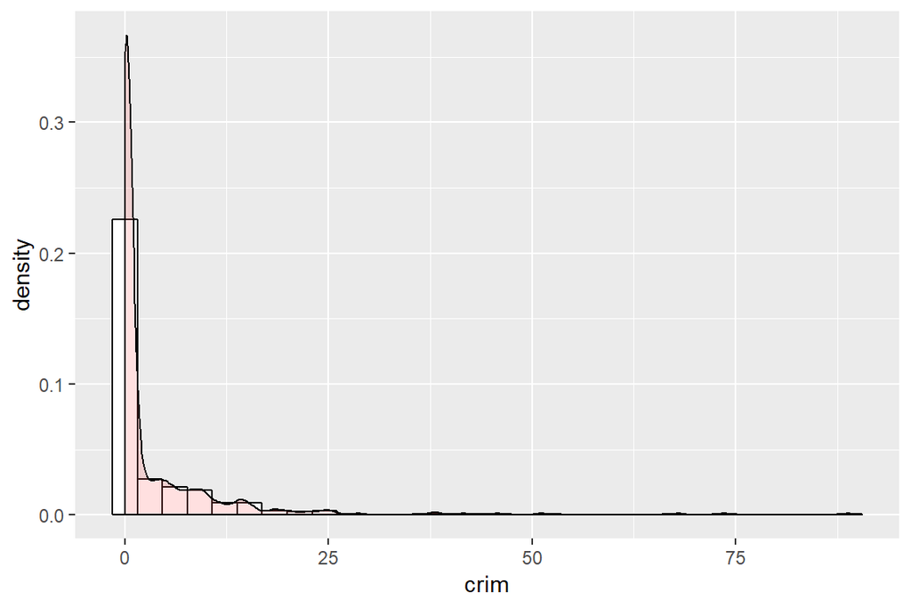

```r
ggplot(Boston, aes(x=crim)) + geom_histogram(aes(y=..density..), colour="black", fill="white")+  geom_density(alpha=.2, fill="#FF6666")
```

Crime rate is continuous variable with great majority at the low end with <1. The range is high with maximum value close to 90.

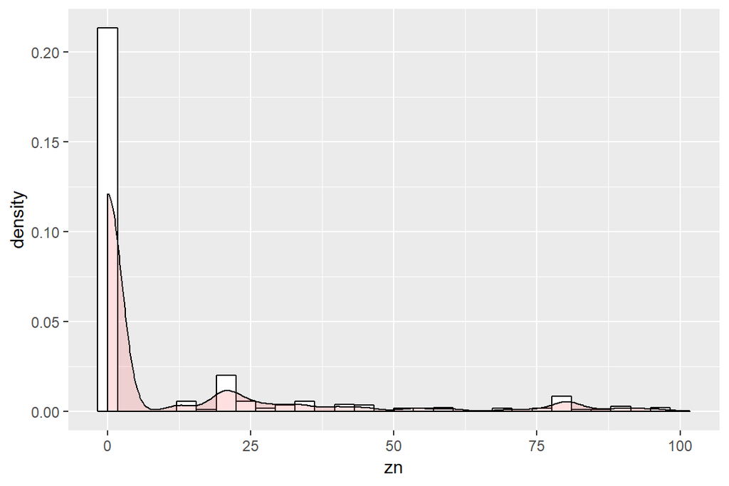

```r
ggplot(Boston, aes(x=zn)) + geom_histogram(aes(y=..density..), colour="black", fill="white")+  geom_density(alpha=.2, fill="#FF6666")
```

proportion of residential land zoned for lots is packed to the low end with median being 0.

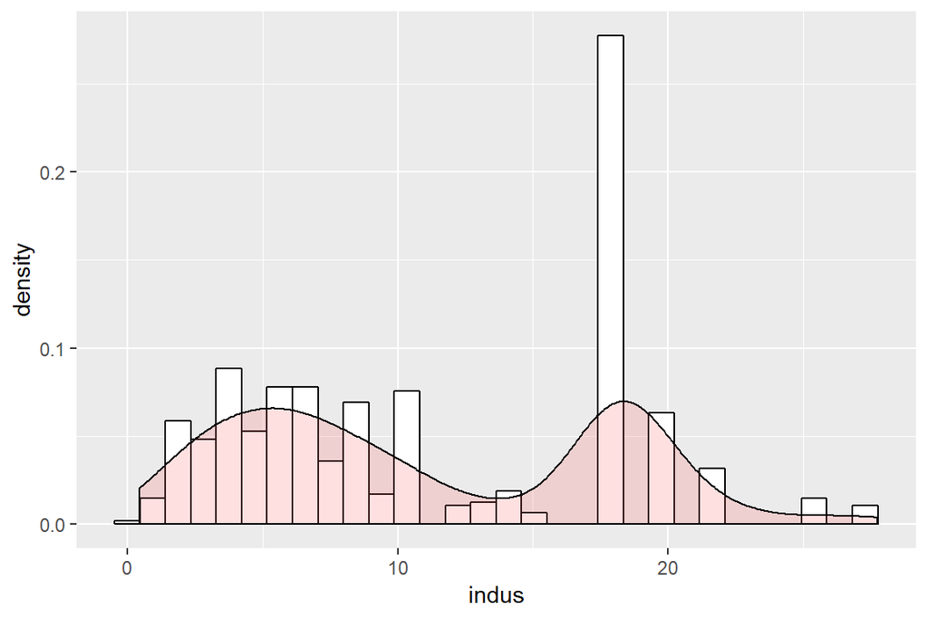

```r
ggplot(Boston, aes(x=indus)) + geom_histogram(aes(y=..density..), colour="black", fill="white")+  geom_density(alpha=.2, fill="#FF6666")
```

proportion of non-retail business acres per town varies between 0-28 with median around 10.

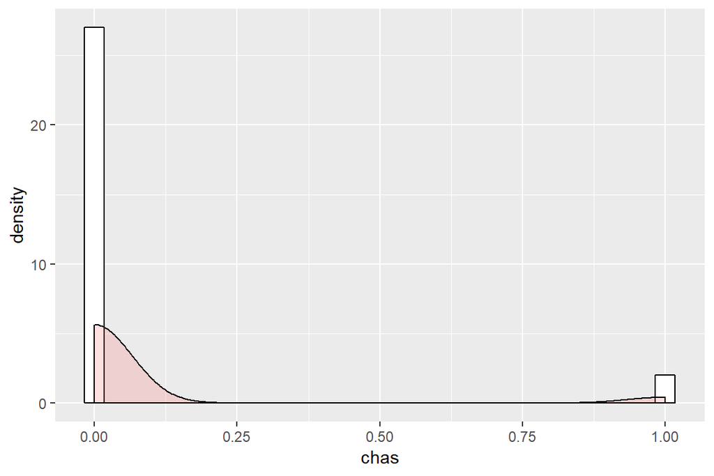

```r
ggplot(Boston, aes(x=chas)) + geom_histogram(aes(y=..density..), colour="black", fill="white")+  geom_density(alpha=.2, fill="#FF6666")
```

chas is a dummy variable with >90% being 0 (not bounding to river)

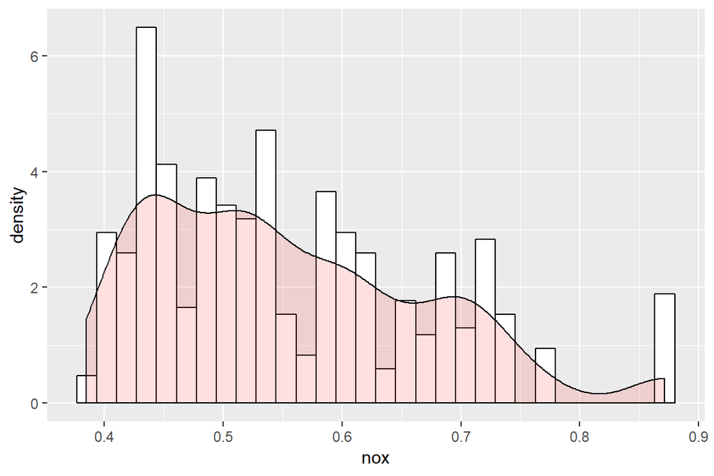

```r
ggplot(Boston, aes(x=nox)) + geom_histogram(aes(y=..density..), colour="black", fill="white")+  geom_density(alpha=.2, fill="#FF6666")
```

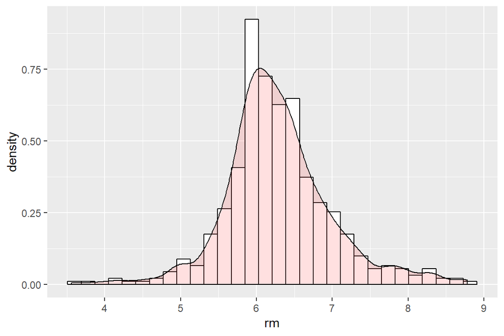

```r
ggplot(Boston, aes(x=rm)) + geom_histogram(aes(y=..density..), colour="black", fill="white")+  geom_density(alpha=.2, fill="#FF6666")
```

number of rooms appeas somewhat normally distributed with median close to 6.

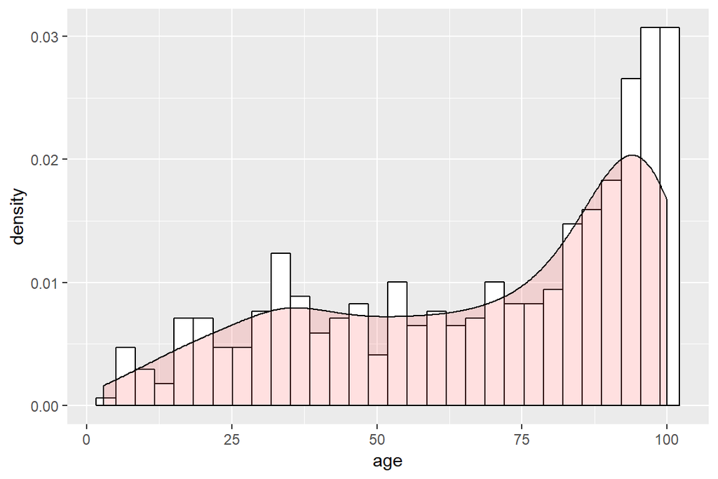

```r
ggplot(Boston, aes(x=age)) + geom_histogram(aes(y=..density..), colour="black", fill="white")+  geom_density(alpha=.2, fill="#FF6666")
```

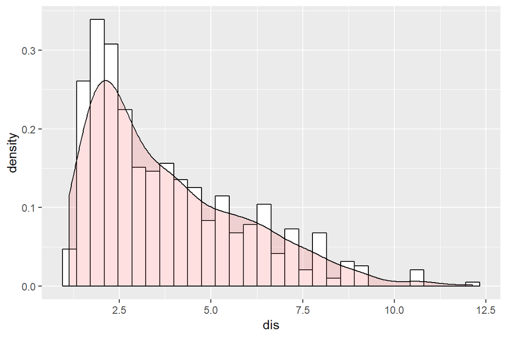

```r
ggplot(Boston, aes(x=dis)) + geom_histogram(aes(y=..density..), colour="black", fill="white")+  geom_density(alpha=.2, fill="#FF6666")
```

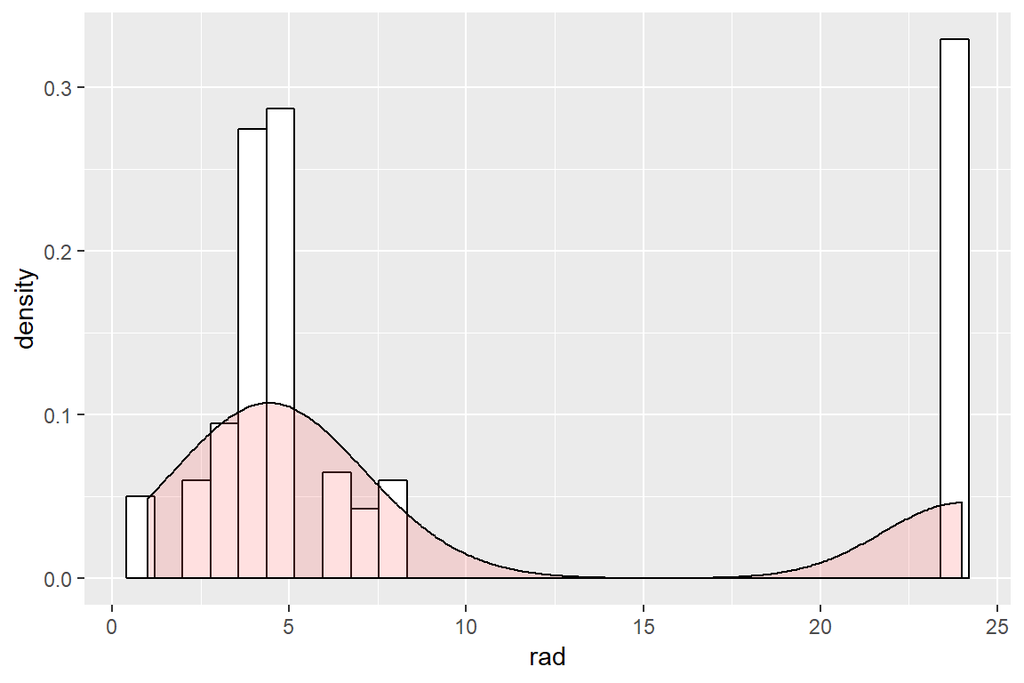

```r
ggplot(Boston, aes(x=rad)) + geom_histogram(aes(y=..density..), colour="black", fill="white")+  geom_density(alpha=.2, fill="#FF6666")
```

access to radial highway is two humped, accessibility is either very low or very high

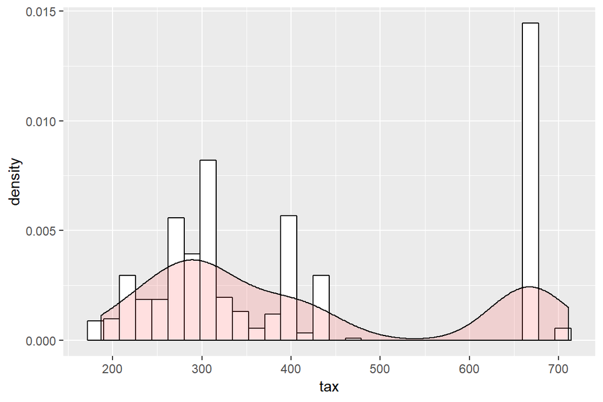

```r
ggplot(Boston, aes(x=tax)) + geom_histogram(aes(y=..density..), colour="black", fill="white")+  geom_density(alpha=.2, fill="#FF6666")
```

property tax rate is mostly between 200-450 but significant amount is focused around 700 as well.

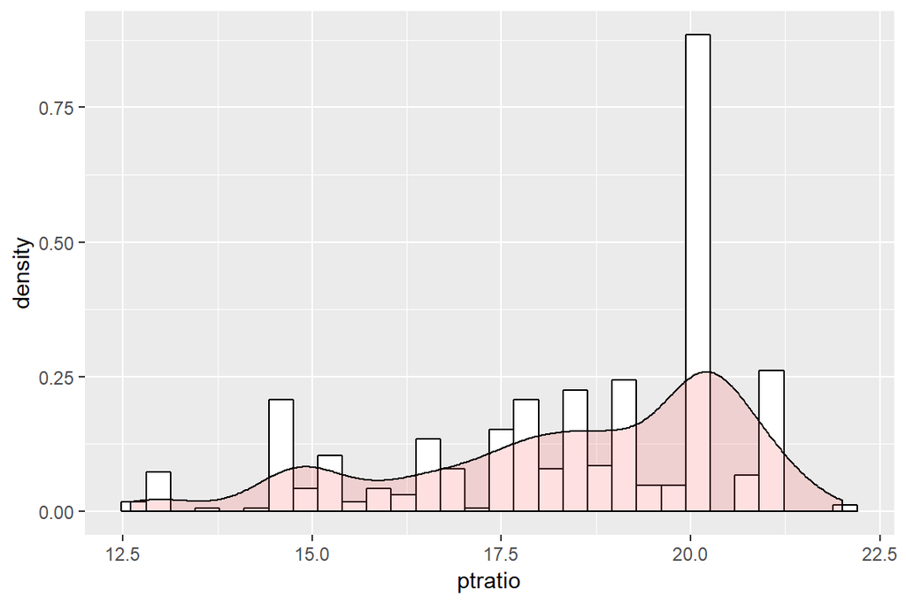

```r
ggplot(Boston, aes(x=ptratio)) + geom_histogram(aes(y=..density..), colour="black", fill="white")+  geom_density(alpha=.2, fill="#FF6666")
```

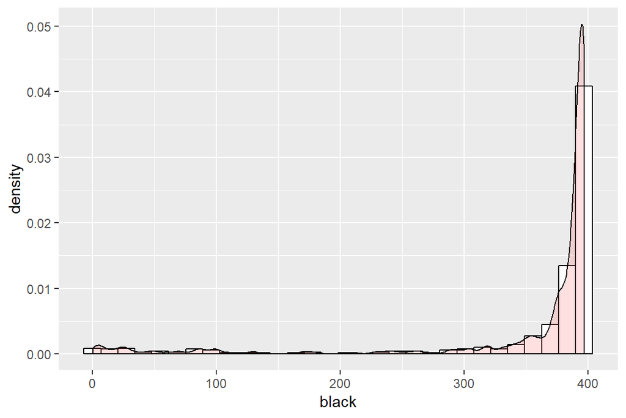

```r
ggplot(Boston, aes(x=black)) + geom_histogram(aes(y=..density..), colour="black", fill="white")+  geom_density(alpha=.2, fill="#FF6666")
```

adjusted black proportion is highly concentrated around 400

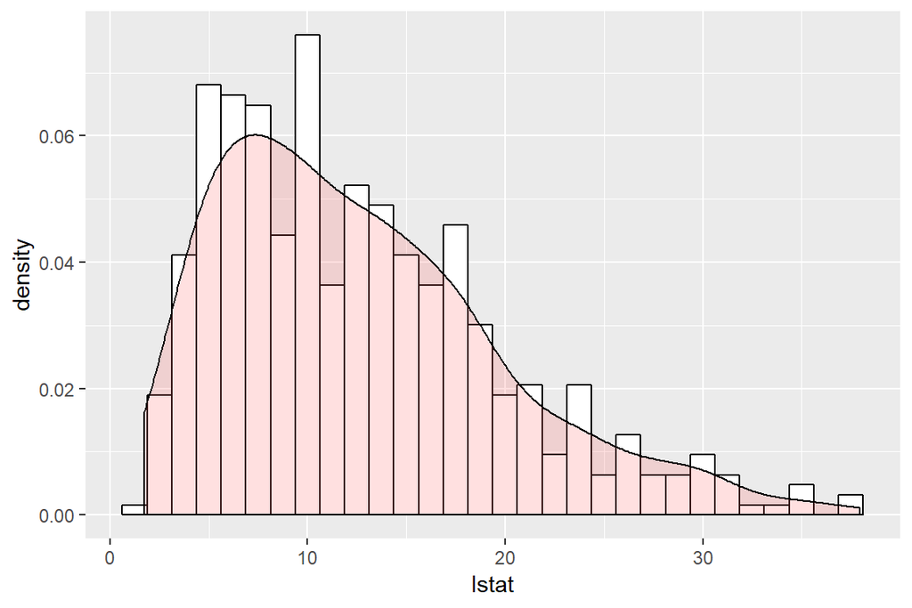

```r
ggplot(Boston, aes(x=lstat)) + geom_histogram(aes(y=..density..), colour="black", fill="white")+  geom_density(alpha=.2, fill="#FF6666")
```

lower status of population is mostly betweeen 0-30 median being around 11

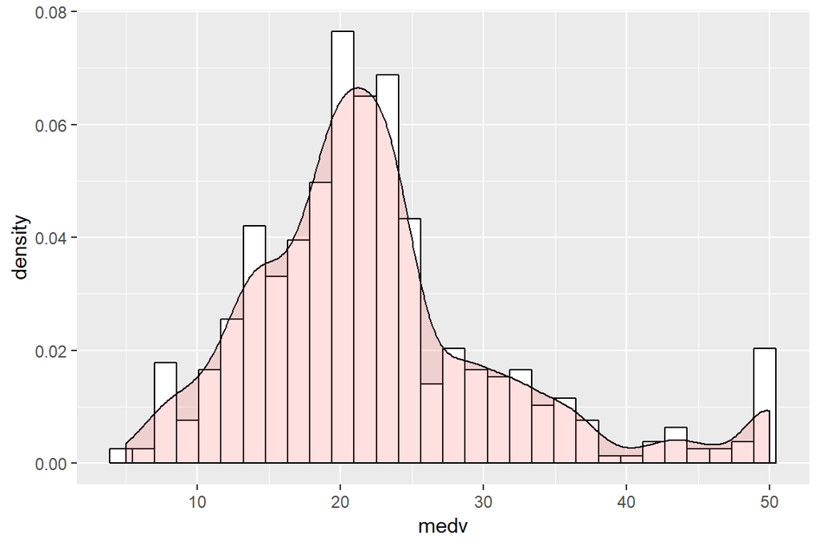

```r
ggplot(Boston, aes(x=medv)) + geom_histogram(aes(y=..density..), colour="black", fill="white")+  geom_density(alpha=.2, fill="#FF6666")
```

median value of owner-occupied homes is 0-50 median being 20.